# 05 · Response magnitude

## Load packages

```r
pacman::p_load(here, limpa, limma, dplyr, tidyr, tibble, purrr, readxl, ggplot2, patchwork,
  writexl)
here::i_am("02_Differential_Expression/05_Response_Magnitude/a_script/05_response_magnitude.qmd")
set.seed(2026)
```

## Question

Protein by protein, BFR and HLRT training do not differ (no interaction hit in `02_Differential`). A response can still be smaller overall, every protein moving the same way but less far, which no single-protein test can see. Three tests ask that:

1. cross-fitted magnitude, as in the YvO Figure 4C: proteins chosen by one arm’s response in half the participants, both arms’ median |log2 change| measured in the other half;
2. a signature score: each leg’s change projected onto the training direction learned from the other participants;
3. fry on the interaction contrast over the proteins that rise, and those that fall, with training.

Comparing hit counts (95 against 218) is not one of them: a difference in significance is not a significant difference.

## Read changes

`proteins_adjusted.rds` gives each leg’s change, T2 minus T1, with the blood index’s effect removed. Only participants with all four biopsies enter, so every comparison is within person.

```r
stage <- here("02_Differential_Expression", "05_Response_Magnitude")
adjusted <- readRDS(here("01_Preprocess", "02_Quantification", "c_data", "proteins_adjusted.rds"))
complete_legs <- adjusted$targets |>
  select(participant, treatment, timepoint, sample_id) |>
  pivot_wider(names_from = c(treatment, timepoint), values_from = sample_id) |>
  drop_na()
bfr <- adjusted$E[, complete_legs$BFR_T2] - adjusted$E[, complete_legs$BFR_T1]
hlrt <- adjusted$E[, complete_legs$HLRT_T2] - adjusted$E[, complete_legs$HLRT_T1]
n <- nrow(complete_legs)
hits <- read_excel(
  here("02_Differential_Expression", "02_Differential", "c_data", "02_differential.xlsx"),
  "contrast_summary"
)
bh_size <- c(
  BFR = hits$n_fdr_05[hits$contrast == "BFR_Post-Pre"],
  HLRT = hits$n_fdr_05[hits$contrast == "HLRT_Post-Pre"]
)
n
```

```
[1] 32
```

```r
bh_size
```

```
 BFR HLRT
  95  218
```

## Cross-fitted magnitude

Choosing proteins by one arm and measuring that arm on the same people inflates it: a protein enters partly because its estimate caught an upward noise draw. So each random split sends half the participants to choose the proteins and the other half to measure both arms on them. Sets run from all proteins to the top 500 and 250 and the BH set (as many proteins as the choosing arm’s BH hits), chosen once by HLRT and once by BFR, over 200 splits. `split_low` and `split_high` are the middle 95% of splits, not a confidence interval. The swap p compares the ratio with 200 data sets in which each participant’s BFR and HLRT labels are swapped at random, the null that the two legs respond alike, each summarised over 200 splits like the observed ratio. All proteins need no choosing arm, so the sheet keeps that row once.

```r
crossfit <- function(bfr, hlrt, splits) {
  map(seq_len(splits), function(split) {
    half <- sample(n, n %/% 2)
    measured <- list(BFR = abs(rowMeans(bfr[, -half])), HLRT = abs(rowMeans(hlrt[, -half])))
    expand_grid(selected_on = c("HLRT", "BFR"), set = c("All", "Top 500", "Top 250", "BH")) |>
      mutate(
        size = case_when(
          set == "All" ~ nrow(bfr), set == "Top 500" ~ 500, set == "Top 250" ~ 250,
          .default = bh_size[selected_on]
        ),
        chosen = map2(selected_on, size, function(arm, size) {
          choose <- abs(rowMeans(list(BFR = bfr, HLRT = hlrt)[[arm]][, half]))
          rank(-choose, ties.method = "first") <= size
        }),
        bfr = map_dbl(chosen, function(k) median(measured$BFR[k])),
        hlrt = map_dbl(chosen, function(k) median(measured$HLRT[k]))
      ) |>
      select(-chosen)
  }) |>
    list_rbind() |>
    mutate(ratio = bfr / hlrt)
}
split_results <- crossfit(bfr, hlrt, 200)
swapped <- map(seq_len(200), function(i) {
  flip <- sample(c(TRUE, FALSE), n, replace = TRUE)
  b <- bfr; h <- hlrt
  b[, flip] <- hlrt[, flip]
  h[, flip] <- bfr[, flip]
  summarise(crossfit(b, h, 200), null_ratio = median(ratio), .by = c(selected_on, set))
}) |>
  list_rbind()
magnitude <- split_results |>
  summarise(
    split_low = quantile(ratio, 0.025), split_high = quantile(ratio, 0.975),
    size = first(size), bfr = median(bfr), hlrt = median(hlrt), ratio = median(ratio),
    .by = c(selected_on, set)
  ) |>
  left_join(summarise(swapped, nulls = list(null_ratio), .by = c(selected_on, set)),
    by = c("selected_on", "set")) |>
  mutate(swap_p = map2_dbl(nulls, ratio, function(null, r) {
    (1 + sum(abs(log(null)) >= abs(log(r)))) / (1 + length(null))
  })) |>
  select(-nulls)
mutate(magnitude, across(where(is.double), function(x) signif(x, 3)))
```

```
# A tibble: 8 × 9
  selected_on set     split_low split_high  size   bfr  hlrt ratio swap_p
  <chr>       <chr>       <dbl>      <dbl> <dbl> <dbl> <dbl> <dbl>  <dbl>
1 HLRT        All         0.774       1.12  3040 0.143 0.153 0.935  0.348
2 HLRT        Top 500     0.616       1.23   500 0.207 0.243 0.862  0.219
3 HLRT        Top 250     0.567       1.39   250 0.242 0.285 0.828  0.234
4 HLRT        BH          0.539       1.43   218 0.249 0.295 0.823  0.234
5 BFR         All         0.774       1.12  3040 0.143 0.153 0.935  0.348
6 BFR         Top 500     0.592       1.06   500 0.185 0.219 0.855  0.214
7 BFR         Top 250     0.482       1.13   250 0.203 0.249 0.82   0.259
8 BFR         BH          0.305       1.16    95 0.23  0.315 0.745  0.249
```

## Signature score

The training direction is the mean change across both arms. For each participant it is learned from the other participants only, over a set fixed before any comparison: the proteins whose average training change across both arms passes BH 0.05 in the limpa model (below). Each leg’s score is its change projected onto that direction; 1 means it moved as far as the average leg of the others. BFR against HLRT is then a paired comparison of one number per participant, tested with a paired t and with 5,000 random sign flips of the per-participant differences.

```r
proteins <- readRDS(here("01_Preprocess", "02_Quantification", "c_data", "proteins.rds"))
d <- readRDS(here("02_Differential_Expression", "01_Design", "c_data", "design.rds"))
coefficient_fit <- dpcDE(proteins, d$design, plot = FALSE)
average <- makeContrasts(average = (BFR_T2 - BFR_T1 + HLRT_T2 - HLRT_T1) / 2, levels = d$design)
average_fit <- topTable(eBayes(contrasts.fit(coefficient_fit, average), robust = TRUE),
  number = Inf, sort.by = "none")
training_set <- list(
  up = rownames(average_fit)[average_fit$adj.P.Val < 0.05 & average_fit$logFC > 0],
  down = rownames(average_fit)[average_fit$adj.P.Val < 0.05 & average_fit$logFC < 0]
)
lengths(training_set)
```

```
  up down
 225  228
```

```r
signature_rows <- rownames(bfr) %in% unlist(training_set)
signature_scores <- map(seq_len(n), function(i) {
  direction <- rowMeans((bfr + hlrt)[signature_rows, -i] / 2)
  tibble(
    participant = complete_legs$participant[i],
    BFR = sum(bfr[signature_rows, i] * direction) / sum(direction^2),
    HLRT = sum(hlrt[signature_rows, i] * direction) / sum(direction^2)
  )
}) |>
  list_rbind()
difference <- signature_scores$BFR - signature_scores$HLRT
flips <- replicate(5000, mean(difference * sample(c(-1, 1), n, replace = TRUE)))
signature_test <- tibble(
  test = "signature score", proteins = sum(signature_rows),
  bfr = mean(signature_scores$BFR), hlrt = mean(signature_scores$HLRT),
  ratio = bfr / hlrt, p = t.test(difference)$p.value,
  swap_p = (1 + sum(abs(flips) >= abs(mean(difference)))) / (1 + length(flips))
)
signature_test
```

```
# A tibble: 1 × 7
  test            proteins   bfr  hlrt ratio      p swap_p
  <chr>              <int> <dbl> <dbl> <dbl>  <dbl>  <dbl>
1 signature score      453 0.810  1.06 0.765 0.0314 0.0300
```

## fry on the interaction

If BFR responds less, the proteins that rise with training rise less in BFR, so their interaction (BFR change minus HLRT change) leans negative, and those that fall lean positive. fry tests each set as a whole in the limpa model with the blood covariate, allowing for correlation between proteins. Choosing sets by the average of the two arms does not bias the interaction, because swapping a participant’s legs leaves the average unchanged.

```r
interaction_contrast <- d$contrasts[, "Modality_x_Time_Interaction"]
interaction_change <- contrasts.fit(coefficient_fit, cbind(interaction_contrast))$coefficients[, 1]
proteins$weights <- coefficient_fit$EList$weights
fry_test <- fry(proteins, training_set, d$design, interaction_contrast, robust = TRUE,
  sort = "none") |>
  as_tibble(rownames = "set") |>
  mutate(
    median_training = map_dbl(training_set, function(rows) median(average_fit[rows, "logFC"])),
    median_interaction = map_dbl(training_set, function(rows) median(interaction_change[rows]))
  )
fry_test
```

```
# A tibble: 2 × 9
  set   NGenes Direction PValue   FDR PValue.Mixed FDR.Mixed median_training
  <chr>  <int> <chr>      <dbl> <dbl>        <dbl>     <dbl>           <dbl>
1 up       225 Down       0.357 0.357        0.278     0.557           0.272
2 down     228 Up         0.130 0.260        0.596     0.596          -0.227
# ℹ 1 more variable: median_interaction <dbl>
```

## Figure

Cross-fitted median |log2 change| per arm, chosen by HLRT (left) and by BFR (right), with the BFR to HLRT ratio and swap p above each pair; below, each participant’s two signature scores.

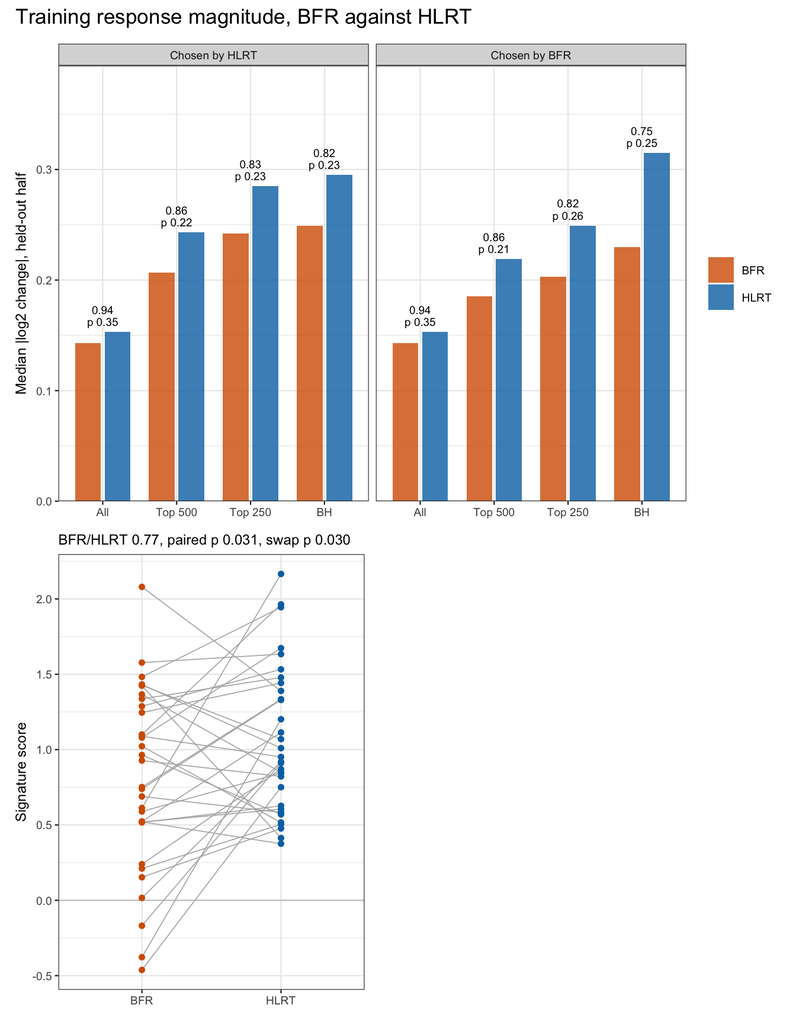

```r
arm_colours <- c(BFR = "#D55E00", HLRT = "#0072B2")
bars <- magnitude |>
  mutate(
    set = factor(set, c("All", "Top 500", "Top 250", "BH")),
    selected_on = factor(paste("Chosen by", selected_on), c("Chosen by HLRT", "Chosen by BFR")),
    label = sprintf("%.2f\np %.2f", ratio, swap_p)
  )
magnitude_plot <- bars |>
  pivot_longer(c(bfr, hlrt), names_to = "arm", values_to = "magnitude") |>
  mutate(arm = toupper(arm)) |>
  ggplot(aes(set, magnitude, fill = arm)) +
  geom_col(position = position_dodge(0.8), width = 0.7, alpha = 0.8) +
  geom_text(data = bars, aes(set, pmax(bfr, hlrt), label = label), inherit.aes = FALSE,
    vjust = -0.3, size = 2.5, lineheight = 0.9) +
  facet_wrap(~selected_on) +
  scale_fill_manual(values = arm_colours) +
  scale_y_continuous(expand = expansion(c(0, 0.25))) +
  labs(x = NULL, y = "Median |log2 change|, held-out half", fill = NULL) +
  theme_bw(base_size = 9)
signature_plot <- signature_scores |>
  pivot_longer(c(BFR, HLRT), names_to = "arm", values_to = "score") |>
  ggplot(aes(arm, score, group = participant)) +
  geom_hline(yintercept = 0, colour = "grey80") +
  geom_line(colour = "grey70", linewidth = 0.3) +
  geom_point(aes(colour = arm), size = 1.4, show.legend = FALSE) +
  scale_colour_manual(values = arm_colours) +
  labs(x = NULL, y = "Signature score",
    subtitle = sprintf("BFR/HLRT %.2f, paired p %.3f, swap p %.3f", signature_test$ratio,
      signature_test$p, signature_test$swap_p)) +
  theme_bw(base_size = 9)
page <- magnitude_plot / (signature_plot | plot_spacer()) +
  plot_annotation(title = "Training response magnitude, BFR against HLRT")
page
```

```r
pdf(file.path(stage, "b_reports", "05_response_magnitude.pdf"), width = 8.27, height = 9)
print(page)
invisible(dev.off())
```

## Save results

```r
write_xlsx(
  list(
    magnitude = magnitude |>
      mutate(selected_on = if_else(set == "All", "none", selected_on)) |>
      distinct(selected_on, set, .keep_all = TRUE),
    signature_scores = signature_scores,
    tests = bind_rows(
      signature_test,
      transmute(fry_test, test = paste("fry", set), proteins = NGenes, median_training,
        median_interaction, direction = Direction, p = PValue)
    )
  ),
  file.path(stage, "c_data", "05_response_magnitude.xlsx")
)
```